# BACI analysis for % Ephemeroptera–Plecoptera–Tricoptera (% EPT)

Valentin Stefan

21 Feb 2021

# 1 Load packages and helper functions

```r
# Source scripts that contains various helper functions for reading and plotting
# data.
source(file = "analysis/baci_glmm/helper-functions.r")
load_install_packages()
```

```
##      glmmTMB   AICcmodavg      lsmeans       DHARMa     parallel   data.table
##         TRUE         TRUE         TRUE         TRUE         TRUE         TRUE
##     magrittr      ggplot2 directlabels
##         TRUE         TRUE         TRUE
```

# 2 Prepare date

```r
# Read data
baci_dt <- fread("data/variables_for_BACI.csv", stringsAsFactors = TRUE)

# Rename some columns:
setnames(baci_dt,
         old = c("BACItime", "BACIpos", "Site", "Ind./m2", "% EPT", "Total organisms", "Total EPT organisms"),
         new = c("period_ba", "treatment_ci", "site_f", "ind_m2", "ept_prc", "N", "N_EPT"))

# Create a factor column `year_f` where I rounded the year to integer and then
# converted to factor type.
baci_dt[, year_f := Year %>% round(digits = 0) %>% factor]

# This will be needed for testing for overdispersation
baci_dt[, obs := 1:.N]

# Prepare % EPT as proportion (ratio)
baci_dt[, ept := N_EPT/N]

# Variable of interest
varb <- "ept"
```

# 3 Exploratory plots

## 3.1 Histogram of the explained variable

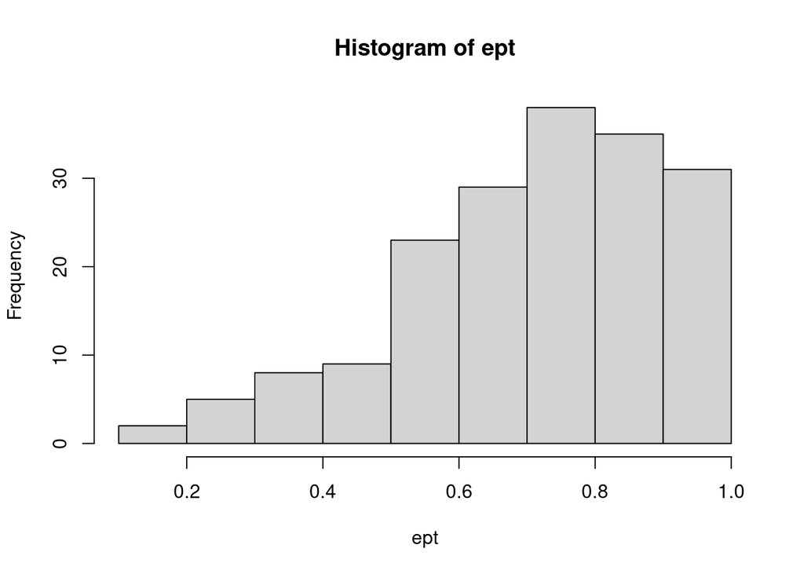

```r
hist(baci_dt[[varb]],
     main = paste("Histogram of" , varb),
     xlab = varb)
```

## 3.2 Preliminary plot

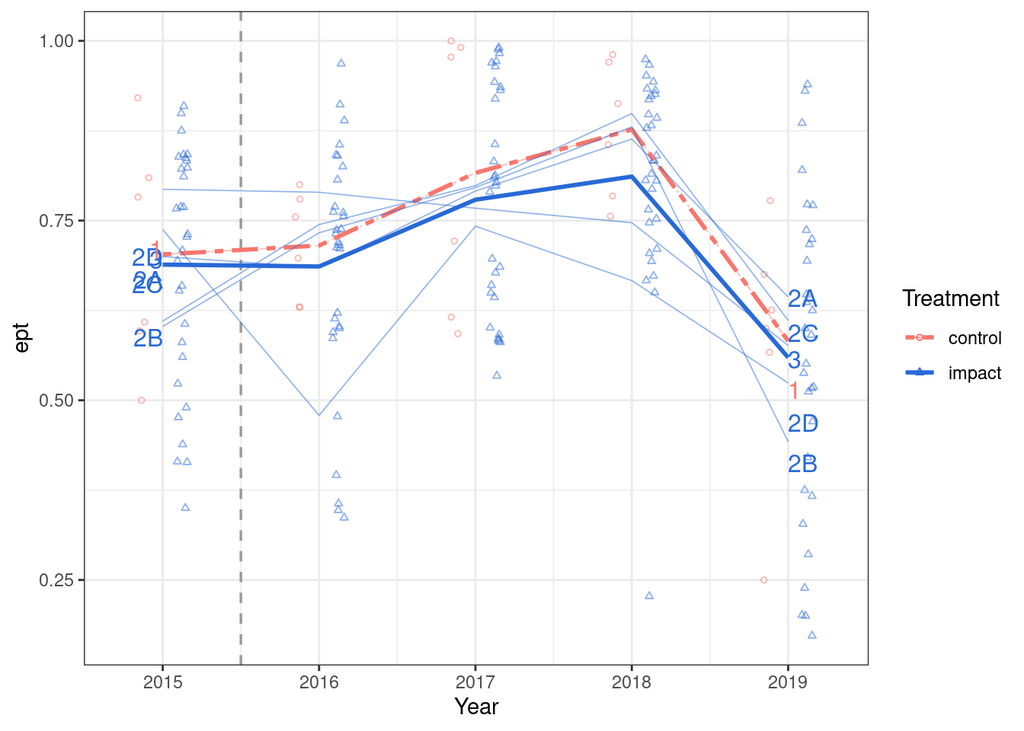

Fig. 1 - Observed values and trends. Thicker lines represent mean lines. Thinner lines stand for each site. There is only one control site which actually overlaps with the mean line for control.

```r
preliminary_plot <- exploratory_plot(varb)
preliminary_plot
```

We can observe already that there is no clear difference between “impact” and “control”. The two mean lines are mostly overlap.

# 4 GLMM fitting

## 4.1 Fixed and random effects

Specify fixed and random effects and test for random effects structure.

The general model formula with fixed effects is `varb ~ period_ba + treatment_ci + period_ba:treatment_ci` Note the interaction term `period_ba:treatment_ci` which is the “BACI effect” (see Schwarz, 2015). Testing for its statistical significance is equivalent to testing for an environmental impact (Schwarz, 2015).

To the fixed effects model, random effects are added: `site_f` and `year_f`.

Below, it was tested if `site_f:year_f` interaction should be kept in the model.

```r
# Create an empty list to be populated with models
models <- list()

# Fit model without the interaction of random effects (site_f and year_f)
models[[1]] <- glmmTMB(N_EPT/N ~ period_ba * treatment_ci + (1|site_f) + (1|year_f),
                       data = baci_dt, weights = N, family = binomial(link = "logit"))

# Model with interaction in the random effects structure
models[[2]] <- glmmTMB(N_EPT/N ~ period_ba * treatment_ci + (1|site_f) + (1|year_f) + (1|site_f:year_f),
                       data = baci_dt, weights = N, family = binomial(link = "logit"))
```

Note that the warnings `'giveCsparse' has been deprecated; setting 'repr = "T"' for you` are expected - see comment of Ben Bolker [here](https://github.com/glmmTMB/glmmTMB/issues/615#issuecomment-763183844).

We could not use the beta distribution for the errors because EPT% is not satisfying the interval 0 < x < 1, as it contains values of 1. Instead, we can consider the variable as a form of success rate from total cases, `N_EPT/N`, where N_EPT and N are integers. In that case we can use the binomial distribution.

Model summary:

```r
summary(models[[1]])
```

```
##  Family: binomial  ( logit )
## Formula:
## N_EPT/N ~ period_ba * treatment_ci + (1 | site_f) + (1 | year_f)
## Data: baci_dt
## Weights: N
##
##      AIC      BIC   logLik deviance df.resid
##   5483.6   5502.8  -2735.8   5471.6      174
##
## Random effects:
##
## Conditional model:
##  Groups Name        Variance Std.Dev.
##  site_f (Intercept) 0.07294  0.2701
##  year_f (Intercept) 0.13147  0.3626
## Number of obs: 180, groups:  site_f, 6; year_f, 5
##
## Conditional model:
##                                    Estimate Std. Error z value Pr(>|z|)
## (Intercept)                         1.10256    0.32707   3.371 0.000749 ***
## period_babefore                    -0.18053    0.42830  -0.421 0.673390
## treatment_ciimpact                 -0.07544    0.29816  -0.253 0.800251
## period_babefore:treatment_ciimpact  0.16141    0.14706   1.098 0.272396
## ---
## Signif. codes:  0 '***' 0.001 '**' 0.01 '*' 0.05 '.' 0.1 ' ' 1
```

```r
summary(models[[2]])
```

```
##  Family: binomial  ( logit )
## Formula:
## N_EPT/N ~ period_ba * treatment_ci + (1 | site_f) + (1 | year_f) +
##     (1 | site_f:year_f)
## Data: baci_dt
## Weights: N
##
##      AIC      BIC   logLik deviance df.resid
##   4011.3   4033.7  -1998.7   3997.3      173
##
## Random effects:
##
## Conditional model:
##  Groups        Name        Variance  Std.Dev.
##  site_f        (Intercept) 3.153e-08 0.0001776
##  year_f        (Intercept) 9.677e-02 0.3110805
##  site_f:year_f (Intercept) 3.059e-01 0.5531091
## Number of obs: 180, groups:  site_f, 6; year_f, 5; site_f:year_f, 30
##
## Conditional model:
##                                    Estimate Std. Error z value Pr(>|z|)
## (Intercept)                         1.17064    0.31950   3.664 0.000248 ***
## period_babefore                    -0.24557    0.72304  -0.340 0.734132
## treatment_ciimpact                 -0.06015    0.30582  -0.197 0.844072
## period_babefore:treatment_ciimpact  0.02682    0.69371   0.039 0.969164
## ---
## Signif. codes:  0 '***' 0.001 '**' 0.01 '*' 0.05 '.' 0.1 ' ' 1
```

The models are compared using the Akaike Information Criterion (AIC). The preferred model should be the one with a smaller AIC value. A model selection approach similar to the one proposed by Burnham & Anderson (2002) is used. The authors suggest the rule of thumb according to which models with AIC difference smaller or equal than 2 (delta-AIC ≤ 2) have substantial empirical support, those with 4 ≤ delta-AIC ≤ 7 have considerably less and those with delta-AIC > 10 have essentially none. On the other hand, they also suggest that the model with delta-AIC > 10 might still be used for inference if the sample size is large.

```r
# AICc comparison
aictab(cand.set = models,
       modnames = c("1-without site_f:year_f",
                    "2-with site_f:year_f"),
       second.ord = TRUE)
```

```
##
## Model selection based on AICc:
##
##                         K    AICc Delta_AICc AICcWt Cum.Wt       LL
## 2-with site_f:year_f    7 4012.00       0.00      1      1 -1998.67
## 1-without site_f:year_f 6 5484.13    1472.13      0      1 -2735.82
```

Additionally to the AIC test, we can also run the likelihood ratio test (LRT) as per Bates (2015).

```r
anova(models[[1]], models[[2]])
```

```
## Data: baci_dt
## Models:
## models[[1]]: N_EPT/N ~ period_ba * treatment_ci + (1 | site_f) + (1 | year_f), zi=~0, disp=~1
## models[[2]]: N_EPT/N ~ period_ba * treatment_ci + (1 | site_f) + (1 | year_f) + , zi=~0, disp=~1
## models[[2]]:     (1 | site_f:year_f), zi=~0, disp=~1
##             Df    AIC    BIC  logLik deviance  Chisq Chi Df Pr(>Chisq)
## models[[1]]  6 5483.6 5502.8 -2735.8   5471.6
## models[[2]]  7 4011.3 4033.7 -1998.7   3997.3 1474.3      1  < 2.2e-16 ***
## ---
## Signif. codes:  0 '***' 0.001 '**' 0.01 '*' 0.05 '.' 0.1 ' ' 1
```

The AIC test favors that the more complex model (with `site_f:year_f`). The LRT test indicates that there are significant differences between the two models. We pick the more complex model for further analysis.

## 4.2 Overdispersion

Testing for overdispersion in the mixed model.

“Overdispersion: the occurrence of more variance in the data than predicted by a statistical model.” (Bolker, 2009). In case of overdispersed then we can fit a model with observation-level random effects see Harrison XA (2014) or Harrison XA (2015). This approach was also suggested by Ben Bolker [here](https://bbolker.github.io/mixedmodels-misc/glmmFAQ.html#overdispersion), where further references are mentioned.

The tests below indicate no significant overdispersion.

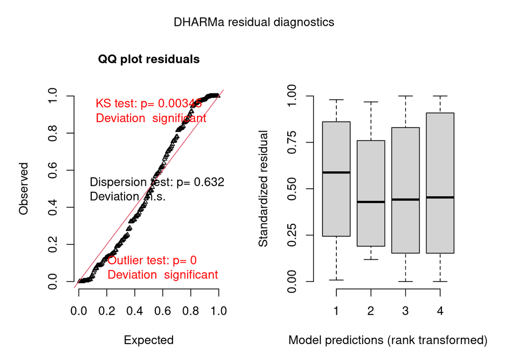

```r
# Test for overdispersion with DHARMa residuals diagnostics
simulation <- DHARMa::simulateResiduals(fittedModel = models[[2]])
plot(simulation)
```

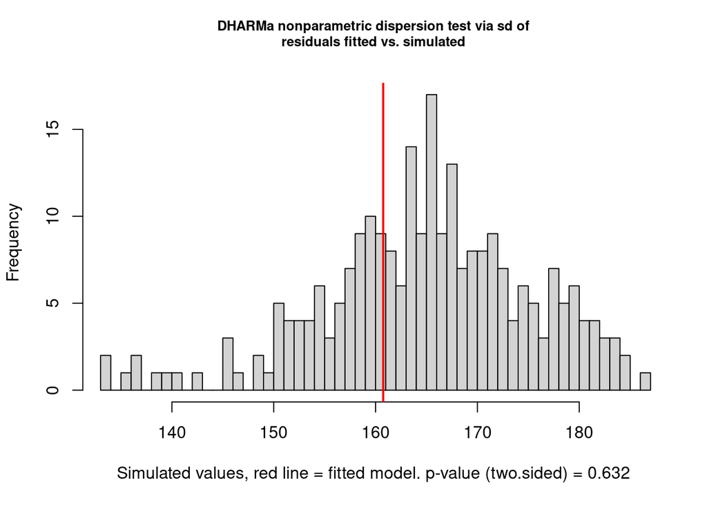

```
##
##  DHARMa nonparametric dispersion test via sd of residuals fitted vs.
##  simulated
##
## data:  simulationOutput
## ratioObsSim = 0.97478, p-value = 0.632
## alternative hypothesis: two.sided
```

```r
# A non-parametric test on the simulated residuals
DHARMa::testDispersion(simulation)
```

We keep the model without any overdispersion adjustments for further analysis.

```r
model <- models[[2]]
```

## 4.3 Diagnostic plots

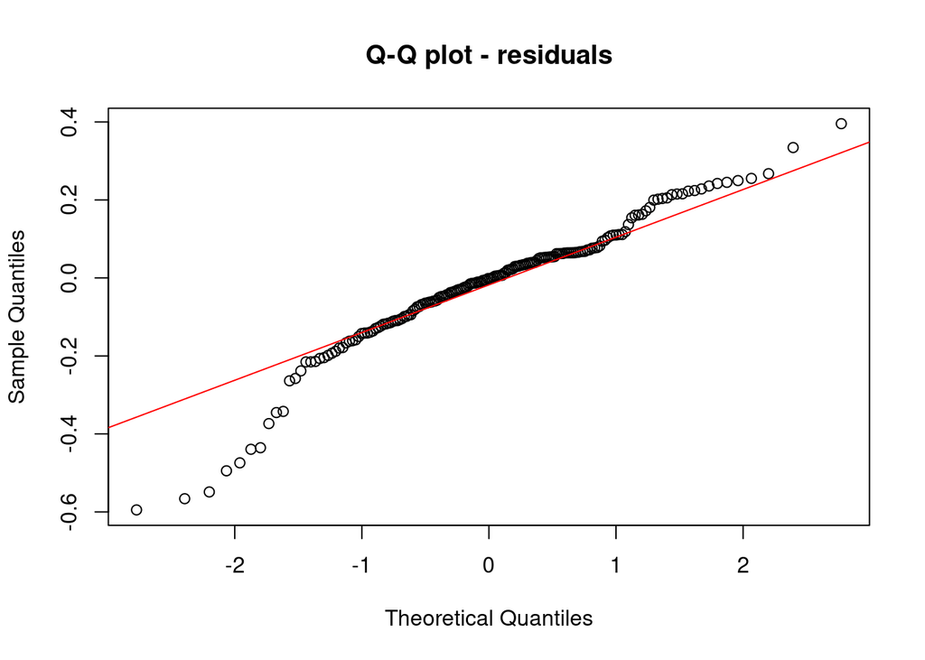

```r
# Residuals
qqnorm(residuals(model), main = "Q-Q plot - residuals")
qqline(residuals(model), col = "red")
```

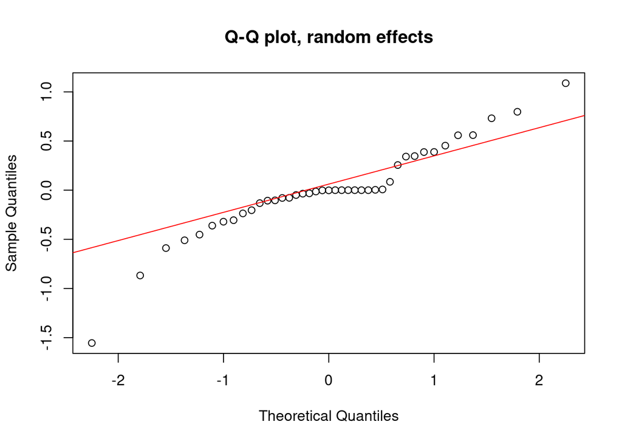

```r
# inspecting the random effects (see also Bolker, 2009 - supp 1)
qqnorm(unlist(ranef(model)), main = "Q-Q plot, random effects")
qqline(unlist(ranef(model)), col = "red")
```

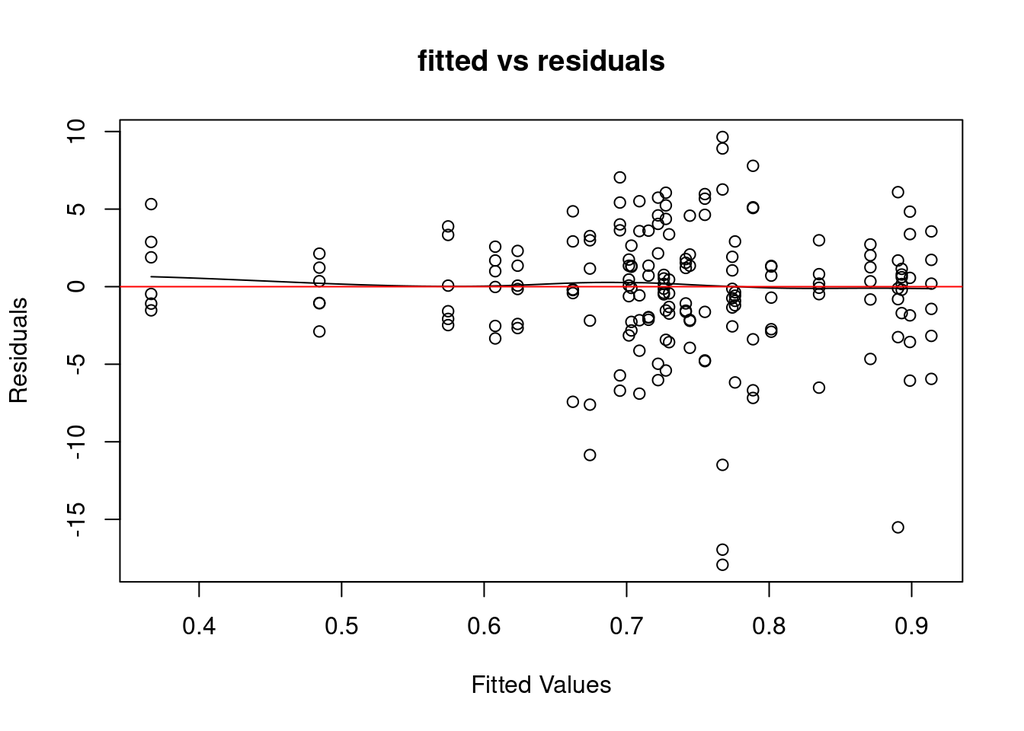

```r
# fitted vs residuals
scatter.smooth(fitted(model),
               residuals(model, type = "pearson"),
               main = "fitted vs residuals",
               xlab = "Fitted Values",
               ylab = "Residuals")
abline(h = 0, col = "red")
```

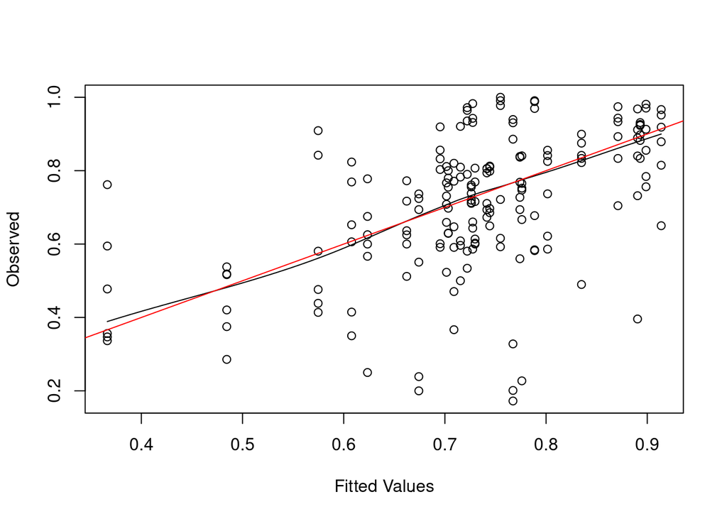

```r
# fitted vs observed
scatter.smooth(fitted(model), baci_dt[[varb]],
               xlab = "Fitted Values",
               ylab = "Observed")
abline(0, 1, col = "red")
```

## 4.4 Significance of BACI

We will test for statistical significance of BACI interaction term using the likelihood ratio test (LRT).

The nested models that we compare are:

- the model without the interaction between the fixed effects (the BACI effect)
- model with the BACI effect

```r
# Model without the BACI interaction term
model.no.interaction <- glmmTMB(N_EPT/N ~ period_ba + treatment_ci + (1|site_f) + (1|year_f) + (1|site_f:year_f),
                                data = baci_dt, weights = N, family = binomial(link = "logit"))

# LRT
lrt <- anova(model, model.no.interaction)
lrt
```

```
## Data: baci_dt
## Models:
## model.no.interaction: N_EPT/N ~ period_ba + treatment_ci + (1 | site_f) + (1 | year_f) + , zi=~0, disp=~1
## model.no.interaction:     (1 | site_f:year_f), zi=~0, disp=~1
## model: N_EPT/N ~ period_ba * treatment_ci + (1 | site_f) + (1 | year_f) + , zi=~0, disp=~1
## model:     (1 | site_f:year_f), zi=~0, disp=~1
##                      Df    AIC    BIC  logLik deviance  Chisq Chi Df Pr(>Chisq)
## model.no.interaction  6 4009.3 4028.5 -1998.7   3997.3
## model                 7 4011.3 4033.7 -1998.7   3997.3 0.0015      1     0.9692
```

The likelihood ratio (LRT) gives no significant p-value. There are no significant differences between the two models. Therefore, the interaction term (BACI effect) is not statistically significant (there is no environmental impact).

## 4.5 Model coefficients

Extract coefficients from final model.

Remove the intercept for extracting group means and their confidence intervals as suggested in Schielzeth H (2010).

```r
final.model <- model
final.model.noIntercept <- update(final.model, . ~ . -1)
```

To get the real proportions (Least-squares means/predicted marginal means/treatment means) one can do:

```r
estimates <- lsmeans::lsmeans(final.model.noIntercept, ~ treatment_ci:period_ba, type = "response")
# https://stats.stackexchange.com/questions/192062/issue-calculating-adjusted-means-for-glmer-model
# Confidence level used: 0.95
estimates
```

```
##  treatment_ci period_ba  prob     SE  df lower.CL upper.CL
##  control      after     0.763 0.0577 173    0.632    0.858
##  impact       after     0.752 0.0372 173    0.672    0.818
##  control      before    0.716 0.1319 173    0.412    0.901
##  impact       before    0.709 0.0826 173    0.525    0.843
##
## Confidence level used: 0.95
## Intervals are back-transformed from the logit scale
```

As indicated in Schwarz CJ (2015), the BACI effect is computed as BACI = avgCA - avgCB - (avgIA - avgIB):

```r
# get the estimates only (without CI)
est <- predict(ref.grid(final.model.noIntercept), type = "response")
# give names to the estimates vector
names(est) <- c("CA","CB","IA","IB"); est
```

```
##        CA        CB        IA        IB
## 0.7632615 0.7160750 0.7522210 0.7092491
```

```r
baci <- est["CA"]-est["CB"]-(est["IA"]-est["IB"])
baci
```

```
##          CA
## 0.004214529
```

One can also get the BACI effect like:

```r
contrast(regrid(estimates), list(baci=c(1,-1,-1,1)))
```

```
##  contrast estimate    SE  df t.ratio p.value
##  baci      0.00421 0.139 173 0.030   0.9758
```

Or with asymptotic CI-s:

```r
baci_ci <- confint(contrast(regrid(estimates), list(baci=c(1,-1,-1,1))))
baci_ci
```

```
##  contrast estimate    SE  df lower.CL upper.CL
##  baci      0.00421 0.139 173   -0.269    0.278
##
## Confidence level used: 0.95
```

```r
# Confidence level used: 0.95
# https://stats.stackexchange.com/questions/241523/testing-for-pairwise-proportion-differences
```

## 4.6 Coefficient of determination (R^2)

Below is presented the coefficient of determination of the correlation between the fitted and observed values as suggested by Ben Bolker [here](https://bbolker.github.io/mixedmodels-misc/glmmFAQ.html#simplecrude-solutions).

```r
r2_corr <- function(m) {
  lmfit <-  lm(model.response(model.frame(m)) ~ fitted(m))
  summary(lmfit)$r.squared
}

R2 <- r2_corr(final.model)
R2
```

```
## [1] 0.2677011
```

## 4.7 Interaction plot

This plot will confirm as well visually that there is no BACI effect. The confidence intervals of the means overlap and the two lines are almost parallel.

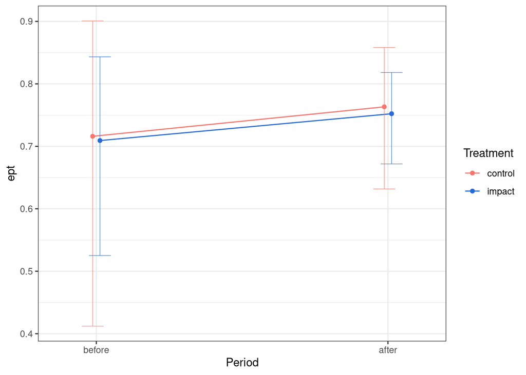

Fig. 2 - Interaction plot for the model. Least square means values. Error bars show the ±95% CI.

```r
interaction_plot(estimates, varb)
```

We can compare the observed mean values (marked with x symbol in the graph below) with the estimated mean values (model coefficients, marked with a plain dot and connected with lines). The estimated means for ept are close to the observed mean values.

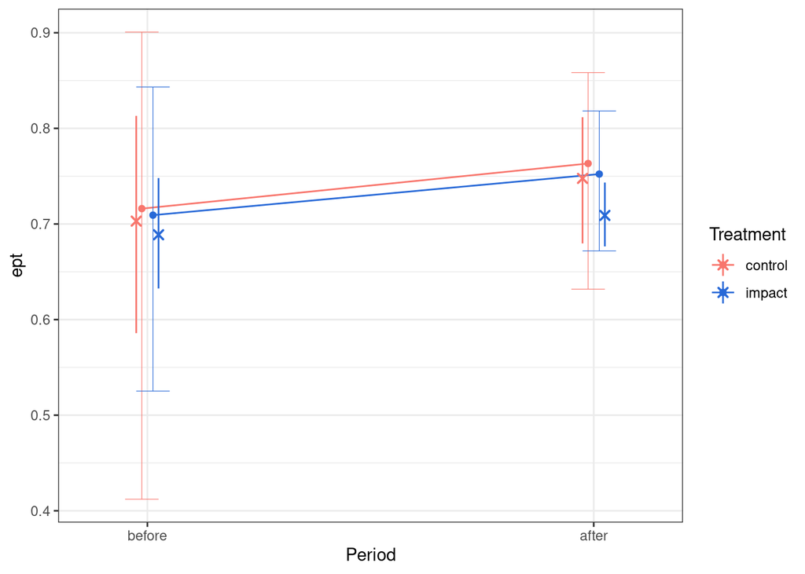

Fig. 3 - Interaction plot depicting both the observed mean values (marked with x) and the estimated mean values (model coefficents, marked with plain dot). Error bars show the ±95% CI.

```r
interaction_plot(estimates, varb) +
  # Add observed means as dots with bootstrapped CIs
  stat_summary(data = baci_dt,
               aes(x = period_ba,
                   y = get(varb),
                   group = treatment_ci,
                   color = treatment_ci),
               fun.data = "mean_cl_boot",
               # geom = "point",
               size = 0.5,
               shape = 4,
               position = position_dodge(width = 0.1),
               show.legend = TRUE)
```

## 4.8 Model summary

The final GLMM model explained 26.77 % of the variance in ept.

There was no significant BACI period × treatment effect (LRT, p = 0.969). The BACI effect estimated from the model, which is the difference of the two changes (control after − control before) − (impact after − impact before]), was 0.004 ± 0.139 standard error.

The estimated mean ept in the control sites varied from 0.72 to 0.76, and in the impact sites varied from 0.71 to 0.75, before and after the construction of the dam (Fig 2 & Fig 3).

# 5 References

Bates, D., Kliegl, R., Vasishth, S., & Baayen, H. (2015). Parsimonious mixed models. arXiv preprint arXiv:1506.04967.

Bolker BM et al. (2009) Generalized linear mixed models: a practical guide for ecology and evolution. Trends in ecology & evolution 24:127–135 at http://www.sciencedirect.com/science/article/pii/S0169534709000196

Burnham, K. & Anderson, D., 2002. Model selection and multimodel inference: a practical information-theoretic approach, New York: Springer.

Harrison XA (2014) Using observation-level random effects to model overdispersion in count data in ecology and evolution. PeerJ 2:e616 https://doi.org/10.7717/peerj.616

Harrison XA (2015) A comparison of observation-level random effect and Beta-Binomial models for modelling overdispersion in Binomial data in ecology & evolution. PeerJ 3:e1114 at https://peerj.com/articles/1114.pdf

Matuschek, H., Kliegl, R., Vasishth, S., Baayen, H., & Bates, D. (2017). Balancing Type I error and power in linear mixed models. Journal of Memory and Language, 94, 305-315.

Schwarz CJ (2015) Analysis of BACI experiments. In Course Notes for Beginning and Intermediate Statistics. at http://people.stat.sfu.ca/~cschwarz/Stat-650/Notes/PDFbigbook-R/R-part013.pdf

Schielzeth H (2010) Simple means to improve the interpretability of regression coefficients. Methods in Ecology and Evolution, 1(2), 103-113.